# Tongfei Li STAC33 A1

```r
library(tidyverse)
```

1(a) First, I put the url of the data file into new variable called my_url. Since the data values are always separated by the same single character, which is a space here, so i use read_delim to read the file. There are 47 rows and 2 columns, as there should be.

```r
my_url <- "http://ritsokiguess.site/STAC32/rainfall.txt"
rainfall <- read_delim(my_url," ")
rainfall
```

| Year | Rainfall |
| --- | --- |
| 1951 | 20.66 |
| 1952 | 16.72 |
| 1953 | 13.51 |
| 1954 | 14.10 |
| 1955 | 25.37 |
| 1956 | 12.05 |
| 1957 | 28.74 |
| 1958 | 10.98 |
| 1959 | 12.55 |
| 1960 | 12.75 |

[output cut: 37 more lines]

1(b) Here, we want to see the rainfall value changes according to the years, so we should put the years in x axis as independent variable, and the rainfall value at y axis as response variable. Since we need to see the rainfall value changes as the year changes, we should treat both rainfall and year as quantitative variables, 2 quantitative variables leads to a scatter plot.

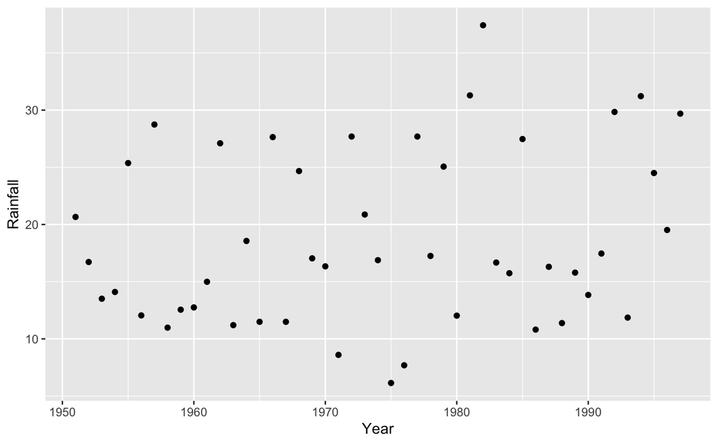

```r
ggplot(rainfall, aes(x = Year, y = Rainfall)) + geom_point()
```

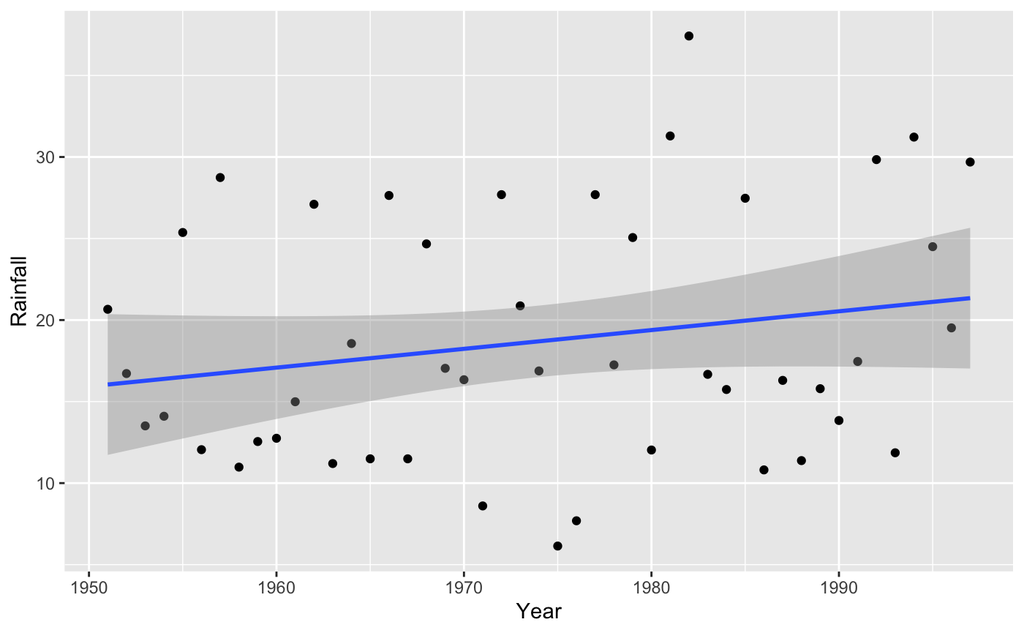

```r
ggplot(rainfall, aes(x = Year, y = Rainfall)) + geom_point() + geom_smooth(method="lm")
```

```r
model1 <- lm(Rainfall ~ Year, data = rainfall)
summary(model1)
```

```
Call:
lm(formula = Rainfall ~ Year, data = rainfall)

Residuals:
    Min      1Q  Median      3Q     Max
-12.670  -5.252  -1.905   7.088  17.804

Coefficients:
              Estimate Std. Error t value Pr(>|t|)
(Intercept) -208.57325  158.42281  -1.317    0.195
Year           0.11513    0.08025   1.435    0.158

Residual standard error: 7.463 on 45 degrees of freedom
Multiple R-squared:  0.04373,   Adjusted R-squared:  0.02248
F-statistic: 2.058 on 1 and 45 DF,  p-value: 0.1583
```

2(a) From the data file, we can see that the laptop and score value are separeted by more than one space, and the spaces between values are not constant, so I used read_table here. There are 47 rows and 2 columns, as there should be. I get correct number of observation 47, and correct type of column. Column 1 is charactor (yes or no) for laptop, which is categorical. Column 2 is double for score that each student get, which is quantitative.

```r
my_url <- "http://ritsokiguess.site/STAC33/algebra.txt"
score <- read_table(my_url)
score
```

| laptop | score |
| --- | --- |
| yes | 98 |
| yes | 84 |
| yes | 97 |
| yes | 93 |
| yes | 88 |
| yes | 57 |
| yes | 100 |
| yes | 84 |
| yes | 100 |
| yes | 81 |

[output cut: 37 more lines]

2(b) Since the laptop here is categorical variable and score here is quantitative variable. 1 categorical and 1 quantitative variable leads to side-by-side box plots.

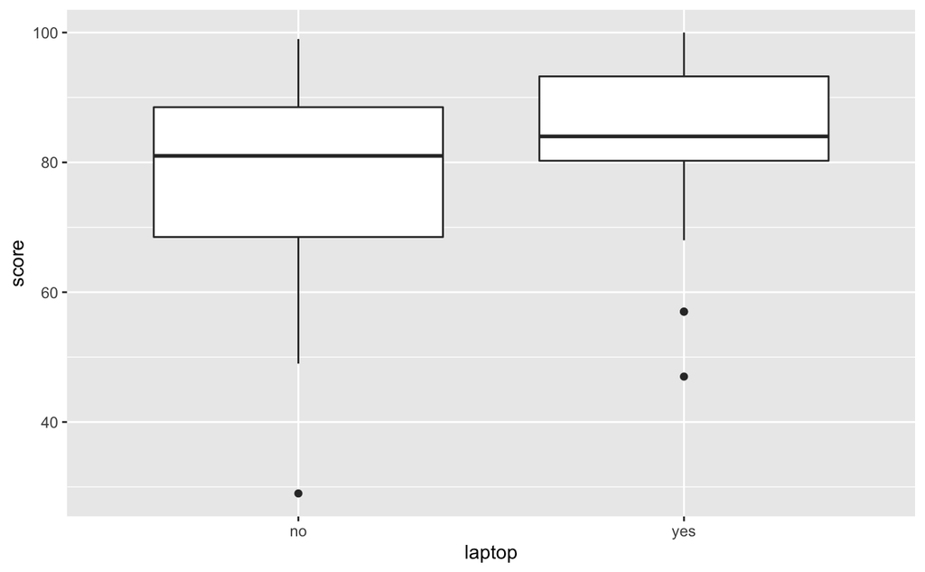

```r
ggplot(score, aes(x = laptop, y = score)) + geom_boxplot()
```

2(d) In the box plot, we can see the median score of students with and without laptop is around 84 and 81, which is consistent with what we get from this question. In the box plot, we can see the 1st and 3rd quartile for students with laptop is around 80 and 93, iqr = 93 - 80 = 13, for students without laptop is aournd 69 and 89, iqr = 89 - 69 = 20, the value we get here is also consistent with box plot.

```r
score %>%
  group_by(laptop) %>%
  summarise(across(where(is_numeric), list(med=~median(.), iqr=~IQR(.))))
```

```
Deprecated
```

|  | laptop | score_med | score_iqr |
| --- | --- | --- | --- |
| 1 | no | 81 | 20 |
| 2 | yes | 84 | 13 |